# RQ2 Data Preparation & Descriptives

AI Surrogate Sample — Import, Cleaning, Exclusions, Reliability

Author

Caroline Müller

Published

May 16, 2026

# 1 Overview

This file covers everything upstream of the inferential RQ2 analyses:

- Raw CSV import and audit
- Type conversion, column renaming, and structural integrity gates
- Sequential exclusion rules (age, completeness, truncation)
- Demographic, textual, and questionnaire descriptives
- LLM score descriptives by condition
- Questionnaire reliability (Cronbach alpha / Omega)
- LLM scoring reliability (ICC)
- CFA on questionnaire items (1-factor vs 3-factor)

**Outputs written to `10_data/80_analyses_exports/`:**

| File | Used by |
| --- | --- |
| `d_rq2_clean.rds` | 20_RQ2_analyses |
| `d_rq3_ai_conditions.rds` | 20_RQ2_analyses, 50_additional_analyses |
| `d_rq3_ai.rds` | 30_RQ3_data |
| `tbl_icc_raw.rds` | 30_RQ3_data (display) |
| `tbl_icc2k_raw.rds` | reference |
| `tbl_word_count_by_condition.rds` | 30_RQ3_data |

# 2 Setup

## 2.1 Environment

## 2.2 Shared Constants

## 2.3 File-Level Constants

# 3 Data Import

## 3.1 Import CSV

```r
d_raw <- read.csv(data_path)
message("Loaded: ", basename(data_path),
        " | Modified: ", format(file.mtime(data_path), "%Y-%m-%d %H:%M"))
```

## 3.2 Import Audit

Table 1: AI Data Import Audit

| Metric | Value |
| --- | --- |
| Source file | 70_merge_outputs_20260412-1426.csv |
| Total rows | 10800 |
| Distinct AI surrogates | 400 |
| Columns | 28 |

# 4 Data Cleaning

## 4.1 Type Conversion and Renaming

## 4.2 Structural Integrity Gates

## 4.3 Add Derived Columns

Condition factors, questionnaire composites, and age numeric:

# 5 Exclusion Rules

## 5.1 Rule 1 — Age (20–69)

## 5.2 Rule 2 — Row Completeness (27 rows per persona)

## 5.3 Rule 3 — Text Truncation (< 75% of target)

## 5.4 Attrition Table

Table 2: Sequential Exclusion Rules Applied to AI Surrogate Sample

| Step | Rule | Removed (Pers.) | Removed (Rows) | AI Surrogates (n) | Rows (n) |
| --- | --- | --- | --- | --- | --- |
| 0 | Raw import | — | — | 400 | 10,800 |
| 1 | Age (20–69) | 2 | 54 | 398 | 10,746 |
| 2 | Completeness (27 rows) | 0 | 0 | 398 | 10,746 |
| 3 | Truncation (75% threshold) | 4 | 108 | 394 | 10,638 |

Note. Steps 1–3 are surrogate-level exclusions. Rule 2 (completeness) filter suspended pending production confirmation.

## 5.5 Final Sample

# 6 Descriptives: Demographics

## 6.1 Age

Table 3: Distribution of AI Surrogates by Age Bracket

| Age Bracket | n | % |
| --- | --- | --- |
| 20-29 | 101 | 25.6% |
| 30-39 | 86 | 21.8% |
| 40-49 | 73 | 18.5% |
| 50-59 | 86 | 21.8% |
| 60-69 | 48 | 12.2% |
| Total | 394 | 100.0% |

Note. Mean age (midpoint estimate) = 41.5 years (SD = 13.1; range: 20–64).

## 6.2 Gender

Table 4: Gender Distribution of AI Surrogate Sample

| Gender | n | % |
| --- | --- | --- |
| Female | 194 | 49.2% |
| Male | 200 | 50.8% |
| Total | 394 | 100.0% |

## 6.3 Education

Table 5: Education Level Distribution of AI Surrogate Sample

| Education Level | n | % |
| --- | --- | --- |
| High School | 134 | 34.0% |
| Some College | 66 | 16.8% |
| Associate's | 17 | 4.3% |
| Bachelor's | 89 | 22.6% |
| Master's | 44 | 11.2% |
| Doctorate | 3 | 0.8% |
| Other | 41 | 10.4% |
| Total | 394 | 100.0% |

# 7 Descriptives: Textual Properties

## 7.1 Word Counts by Condition

Table 6: Descriptive Statistics for Actual Word Counts by Experimental Condition

| Condition | Target (w) | Texts (n) | M | SD | Min | Max | n |
| --- | --- | --- | --- | --- | --- | --- | --- |
| short-1 | 50 | 1 | 51.3 | 2.4 | 44 | 64 | 1,182 |
| short-3 | 50 | 3 | 152.1 | 6.2 | 128 | 166 | 1,182 |
| short-5 | 50 | 5 | 252.6 | 10.1 | 214 | 274 | 1,182 |
| medium-1 | 150 | 1 | 150.6 | 8.2 | 120 | 175 | 1,182 |
| medium-3 | 150 | 3 | 433.4 | 24.4 | 355 | 514 | 1,182 |
| medium-5 | 150 | 5 | 711.5 | 41.2 | 587 | 830 | 1,182 |
| long-1 | 300 | 1 | 273.1 | 14.9 | 228 | 316 | 1,182 |
| long-3 | 300 | 3 | 782.6 | 44.4 | 635 | 907 | 1,182 |
| long-5 | 300 | 5 | 1,289.1 | 71.2 | 1,047 | 1,497 | 1,182 |

## 7.2 Truncation Compliance

Table 7: Text Length Compliance by Target Word Count (75% Threshold)

| Target (w) | Planned (N) | Failed (n) | Compliant (n) | Compliance (%) |
| --- | --- | --- | --- | --- |
| 50 | 3,546 | 0 | 3,546 | 100.0% |
| 150 | 3,546 | 0 | 3,546 | 100.0% |
| 300 | 3,546 | 0 | 3,546 | 100.0% |

Note. Compliance = actual_words ≥ 75% of target. N aggregated across text-count variants and repeats.

# 8 Descriptives: Questionnaire Scores

## 8.1 Item-Level Statistics

Table 8: Questionnaire Item-Level Descriptives (AI Surrogate Sample)

| Subscale | Item | M | SD | Md | n |
| --- | --- | --- | --- | --- | --- |
| Autonomy | aut_1 | 3.21 | 0.70 | 3 | 394 |
| Autonomy | aut_2 | 2.87 | 0.76 | 3 | 394 |
| Autonomy | aut_3 | 2.85 | 0.90 | 3 | 394 |
| Autonomy | aut_4 | 4.01 | 0.57 | 4 | 394 |
| Competence | com_1 | 4.40 | 0.49 | 4 | 394 |
| Competence | com_2 | 4.45 | 0.50 | 4 | 394 |
| Competence | com_3 | 3.88 | 0.44 | 4 | 394 |
| Competence | com_4 | 4.04 | 0.44 | 4 | 394 |
| Relatedness | rel_1 | 3.99 | 0.46 | 4 | 394 |
| Relatedness | rel_2 | 3.93 | 0.45 | 4 | 394 |
| Relatedness | rel_3 | 3.48 | 0.72 | 4 | 394 |
| Relatedness | rel_4 | 4.04 | 0.51 | 4 | 394 |

Note. N = 394 AI surrogates. Items scored 1–5.

## 8.2 Composite Means by Need

Table 9: Questionnaire Composite Score Descriptives by Need Dimension

| Need Dimension | M | SD | Md | Min | Max | n |
| --- | --- | --- | --- | --- | --- | --- |
| Autonomy | 3.24 | 0.49 | 3.25 | 2.00 | 4.5 | 394 |
| Competence | 4.19 | 0.34 | 4.00 | 3.25 | 5.0 | 394 |
| Relatedness | 3.86 | 0.42 | 4.00 | 2.25 | 5.0 | 394 |

Note. N = 394 AI surrogates. Composite = mean of 4 items per need.

## 8.3 Norms Comparison (Olafsen et al., 2021)

Table 10: Comparison of AI Surrogate Questionnaire Scores with Human Norms (Olafsen et al., 2021)

| Need Dimension | Norm M | Norm SD | Surrogate M | Surrogate SD | Delta M | Delta SD |
| --- | --- | --- | --- | --- | --- | --- |
| Autonomy | 3.52 | 0.59 | 3.24 | 0.49 | -0.28 | -0.10 |
| Competence | 3.86 | 0.56 | 4.19 | 0.34 | 0.33 | -0.22 |
| Relatedness | 3.76 | 0.63 | 3.86 | 0.42 | 0.10 | -0.21 |

Note. Norms from Olafsen et al. (2021), Sample 4 (N = 393), rescaled from 1–7 to 1–5 scale. AI Surrogate N = 394.

# 9 Descriptives: LLM Scores

## 9.1 LLM Score Distributions by Condition

Table 11: LLM Score Descriptives by Condition and Need Dimension (Surrogate-Level Means)

| Condition | Need | M | SD | Min | Max | n |
| --- | --- | --- | --- | --- | --- | --- |
| short-1 | Autonomy | 2.72 | 0.47 | 2.00 | 4.00 | 394 |
| short-1 | Competence | 3.28 | 0.43 | 2.33 | 4.00 | 394 |
| short-1 | Relatedness | 2.99 | 0.28 | 2.00 | 4.00 | 394 |
| short-3 | Autonomy | 2.94 | 0.40 | 2.00 | 4.67 | 394 |
| short-3 | Competence | 3.41 | 0.47 | 2.33 | 4.67 | 394 |
| short-3 | Relatedness | 3.07 | 0.40 | 2.00 | 4.00 | 394 |
| short-5 | Autonomy | 2.98 | 0.41 | 2.00 | 4.00 | 394 |
| short-5 | Competence | 3.49 | 0.47 | 2.00 | 4.33 | 394 |
| short-5 | Relatedness | 3.19 | 0.41 | 2.00 | 4.00 | 394 |
| medium-1 | Autonomy | 3.14 | 0.39 | 2.00 | 4.00 | 394 |
| medium-1 | Competence | 3.67 | 0.44 | 3.00 | 5.00 | 394 |
| medium-1 | Relatedness | 3.24 | 0.40 | 2.33 | 4.00 | 394 |
| medium-3 | Autonomy | 3.17 | 0.43 | 2.00 | 4.00 | 394 |
| medium-3 | Competence | 3.82 | 0.37 | 2.67 | 5.00 | 394 |
| medium-3 | Relatedness | 3.34 | 0.45 | 2.33 | 4.67 | 394 |
| medium-5 | Autonomy | 3.16 | 0.45 | 2.00 | 5.00 | 394 |
| medium-5 | Competence | 3.86 | 0.35 | 3.00 | 5.00 | 394 |
| medium-5 | Relatedness | 3.42 | 0.46 | 2.67 | 4.00 | 394 |
| long-1 | Autonomy | 3.28 | 0.43 | 2.33 | 5.00 | 394 |
| long-1 | Competence | 3.89 | 0.37 | 2.33 | 5.00 | 394 |
| long-1 | Relatedness | 3.44 | 0.46 | 3.00 | 4.33 | 394 |
| long-3 | Autonomy | 3.29 | 0.46 | 2.00 | 4.33 | 394 |
| long-3 | Competence | 3.92 | 0.36 | 3.00 | 5.00 | 394 |
| long-3 | Relatedness | 3.45 | 0.46 | 2.67 | 4.00 | 394 |
| long-5 | Autonomy | 3.30 | 0.46 | 2.00 | 5.00 | 394 |
| long-5 | Competence | 3.97 | 0.33 | 3.00 | 5.00 | 394 |
| long-5 | Relatedness | 3.56 | 0.46 | 3.00 | 4.00 | 394 |

Note. N per condition = 394 AI surrogates. Scores = mean of 3 scoring repeats per persona.

## 9.2 LLM Score Distribution — Boxplots by Condition

Figure 1: LLM Score Distributions by Condition and Need Dimension (Surrogate-Level Means). Each box represents one experimental condition (target word length × number of texts).

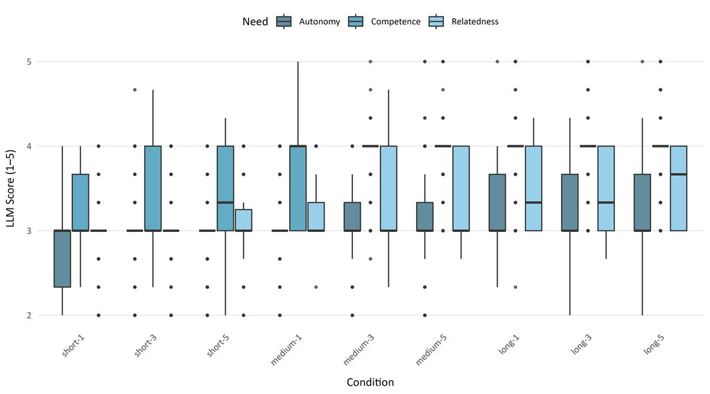

## 9.3 LLM vs Questionnaire Score Overlay

Figure 2: LLM vs Questionnaire Score Distributions by Need Dimension. Blue = LLM scores; gray = questionnaire scores.

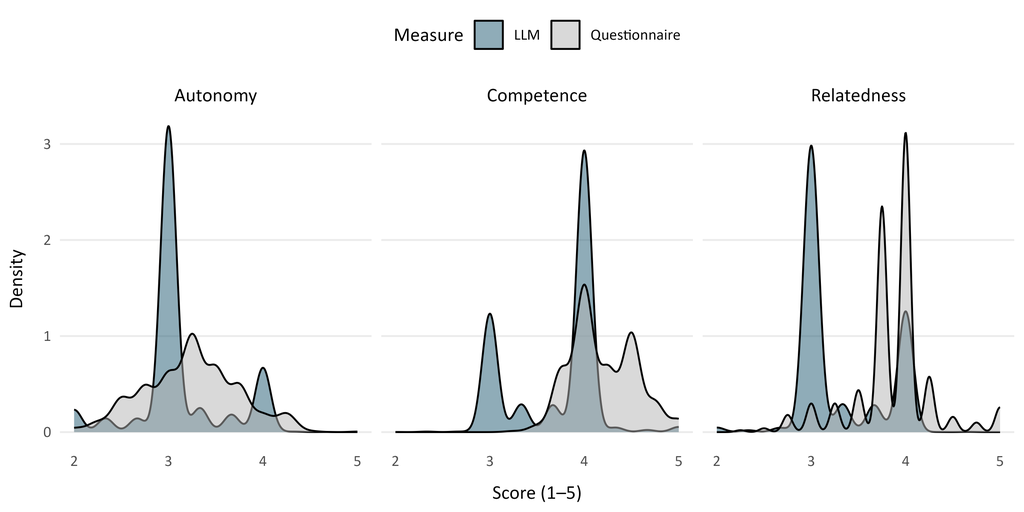

# 10 Reliability

## 10.1 Questionnaire Reliability (Cronbach Alpha / Omega)

Table 12: Internal Consistency of Questionnaire Subscales (Cronbach’s Alpha and McDonald’s Omega)

| Need | Items | Alpha | Omega |
| --- | --- | --- | --- |
| Autonomy | 4 | 0.58 | 0.73 |
| Competence | 4 | 0.71 | 0.74 |
| Relatedness | 4 | 0.77 | 0.83 |

Note. N = 394. Alpha = Cronbach's alpha (raw). Omega = McDonald's omega (total). Items scored 1–5.

## 10.2 LLM Scoring Reliability — ICC(2,1) and ICC(2,3)

ICC(2,1) characterises single-draw reliability; ICC(2,3) characterises the reliability of the mean across k = 3 scoring repeats, which is the quantity used in all downstream analyses.

[output not shown]

[output not shown]

[output not shown]

[output not shown]

Table 13: LLM Scoring Reliability: ICC(2,1) — Two-Way Random Effects, Absolute Agreement, Single Measures

| Condition | ICC(2,1) [95% CI] Autonomy | ICC(2,1) [95% CI] Competence | ICC(2,1) [95% CI] Relatedness |
| --- | --- | --- | --- |
| short-1 | 0.77 [0.73, 0.80] | 0.82 [0.79, 0.85] | 0.73 [0.69, 0.76] |
| short-3 | 0.76 [0.73, 0.79] | 0.81 [0.78, 0.84] | 0.83 [0.81, 0.86] |
| short-5 | 0.75 [0.72, 0.79] | 0.76 [0.72, 0.79] | 0.81 [0.78, 0.84] |
| medium-1 | 0.79 [0.75, 0.82] | 0.76 [0.73, 0.80] | 0.78 [0.75, 0.81] |
| medium-3 | 0.74 [0.70, 0.77] | 0.74 [0.70, 0.78] | 0.79 [0.75, 0.82] |
| medium-5 | 0.76 [0.73, 0.80] | 0.68 [0.64, 0.73] | 0.81 [0.78, 0.83] |
| long-1 | 0.78 [0.74, 0.81] | 0.75 [0.72, 0.79] | 0.80 [0.76, 0.82] |
| long-3 | 0.82 [0.79, 0.84] | 0.80 [0.77, 0.83] | 0.78 [0.75, 0.81] |
| long-5 | 0.80 [0.77, 0.83] | 0.73 [0.70, 0.77] | 0.79 [0.76, 0.82] |

Note. Two-way random effects model, absolute agreement, single measures. Computed via psych::ICC with missing = TRUE.

[output not shown]

[output not shown]

[output not shown]

[output not shown]

```
Reliability Alert: 5 condition × need cell(s) with ICC(2,1) < .75:
```

```
# A tibble: 5 × 5
  Condition Need      ICC CI_lo CI_hi
  <chr>     <chr>   <dbl> <dbl> <dbl>
1 short-1   llm_rel 0.726 0.686 0.763
2 medium-3  llm_aut 0.738 0.700 0.774
3 medium-3  llm_com 0.742 0.704 0.777
4 medium-5  llm_com 0.685 0.640 0.726
5 long-5    llm_com 0.734 0.696 0.770
```

Table 14: LLM Scoring Reliability: ICC(2,3) — Two-Way Random Effects, Absolute Agreement, Average of k = 3 Measures

| Condition | ICC(2,3) [95% CI] Autonomy | ICC(2,3) [95% CI] Competence | ICC(2,3) [95% CI] Relatedness |
| --- | --- | --- | --- |
| short-1 | 0.91 [0.89, 0.92] | 0.93 [0.92, 0.94] | 0.89 [0.87, 0.91] |
| short-3 | 0.91 [0.89, 0.92] | 0.93 [0.92, 0.94] | 0.94 [0.93, 0.95] |
| short-5 | 0.90 [0.88, 0.92] | 0.90 [0.89, 0.92] | 0.93 [0.91, 0.94] |
| medium-1 | 0.92 [0.90, 0.93] | 0.91 [0.89, 0.92] | 0.91 [0.90, 0.93] |
| medium-3 | 0.89 [0.87, 0.91] | 0.90 [0.88, 0.91] | 0.92 [0.90, 0.93] |
| medium-5 | 0.91 [0.89, 0.92] | 0.87 [0.84, 0.89] | 0.93 [0.91, 0.94] |
| long-1 | 0.91 [0.90, 0.93] | 0.90 [0.88, 0.92] | 0.92 [0.91, 0.93] |
| long-3 | 0.93 [0.92, 0.94] | 0.92 [0.91, 0.94] | 0.91 [0.90, 0.93] |
| long-5 | 0.92 [0.91, 0.94] | 0.89 [0.87, 0.91] | 0.92 [0.91, 0.93] |

Note. Two-way random effects model, absolute agreement, average of k = 3 measures (Shrout & Fleiss ICC(2,k)). The three scoring repeats are treated as exchangeable raters. ICC(2,3) reflects reliability of the mean score used in downstream analyses.

## 10.3 CFA on Questionnaire Items (1-Factor vs 3-Factor)

We fit a 1-factor (general valence) and 3-factor (SDT need structure) CFA on the 12 questionnaire items (one row per persona) and compare fit indices. The chi-square difference test between these models is an approximation: strict nesting would require constraining the 3-factor inter-factor correlations to 1.0; the LRT here serves as a descriptive comparison of fit improvement only.

Table 15: CFA Model Fit: 1-Factor vs 3-Factor Questionnaire Structure

| Model | chi-sq | df | p | CFI | RMSEA | SRMR |
| --- | --- | --- | --- | --- | --- | --- |
| 1-factor | 645.803 | 54 | 0 | 0.485 | 0.167 | 0.140 |
| 3-factor | 234.800 | 51 | 0 | 0.840 | 0.096 | 0.073 |

Note. N = 394 AI surrogates. Chi-square difference test between models is an approximation (models are not strictly nested without constraining 3-factor inter-correlations to 1.0).

# 11 Exports

# 12 Session Info